# GLM.H2O2

Fabian Blombach

07/06/2019

This script describes the generation of generalised linear models for the progression of TEC-Spt4/5-Elf1 into productive transcription during oxidative stress. Negative binomial models were used to model count data that showed overdispersion. Raw coverage of Elf1 in the TU body region was modelled. The normalisation against the chromatin input was built into the model by including an offest term with raw chromatin input coverage.

```bash
export PATH=$PATH:/Users/fabianblombach/miniconda3/bin
if [ -d temp ]; then rm -Rf temp; fi
mkdir temp
bedtools slop -i $TSS -g  ../Genomes/Sso_NCBI/SsoP2.sizes -s -l 7 -r 4 > temp/slop.bed

bedtools getfasta -name -s -bed temp/slop.bed -fi ../Genomes/Sso_NCBI/NC_002754.fna -fo temp/DNA.fasta
```

```r
#Temperature in Kelvin
temp=349.15
#Salt concentration in molar
salt= 0.025

#load reference values from SantaLucia Jr paper (PNAS 1998)
NN<-read.table("~/HTS/scripts/NN_thermodynamics.txt", header=T, sep="\t")
NN$ΔH<-as.numeric(as.character(NN$ΔH))
NN$ΔS<-as.numeric(as.character(NN$ΔS))
#delH is in kcal/mol, while delS is in cal/mol*k, calculate the delG in kcal/mol
NN$ΔG <- NN$ΔH - (NN$ΔS*temp/1000)

#load alignment of promoter sequences (output from bedtools getfasta -tab)
require(seqinr)
input<-read.fasta("temp/DNA.fasta", forceDNAtolower=T)
mono<-as.data.frame(matrix(unlist(input), nrow=length(input), byrow=T), row.names=names(input))
row.names(mono)<-gsub('(+)',"",row.names(mono), fixed=T)
row.names(mono)<-gsub('(-)',"",row.names(mono), fixed=T)
# loop to make table with dinucleotides
dinuc<-matrix(rep("N", times=nrow(mono)*(ncol(mono)-1)), nrow=nrow(mono))
for (j in 1:nrow(mono)) {
  for (i in 1:(ncol(mono)-1)) {
  dinuc[j,i] <- paste0(mono[j,i], mono[j,i+1])
  }
}
# replace dinucleotides with corresponding deltaG values
dinucG<-dinuc
for (k in 1:16) {
dinucG[dinucG == NN[k,1]]<- NN[k,4]
}
dinucG<-data.frame(matrix(as.numeric(dinucG), ncol=ncol(dinuc)))


# replace monocleotides with corresponding deltaG values for terminal nucleotides
monoG<-as.matrix(mono, nrow=nrow(mono))
for (k in 17:20) {
  monoG[monoG == NN[k,1]]<- NN[k,4]
}
monoG<-data.frame(matrix(as.numeric(monoG), ncol=ncol(monoG)))
```

calculate Elf1Bd and input occupancy for linear modelling

```bash
export PATH=$PATH:/Users/fabianblombach/miniconda3/bin

#calculate input coverage
computeMatrix reference-point --sortRegions keep -bs 1 -a 500 -b 0 -R $TSS -S $Inp1 $Inp2 $Spt45_r1 $Spt45_r2 $Elf1_r1 $Elf1_r2 -o temp/trashme.npz --outFileNameMatrix temp/trashme.tab;
rm temp/trashme.npz;
head -n 2 temp/trashme.tab > temp/Coverage.tab;
tail -n $nrows temp/trashme.tab >> temp/Coverage.tab; rm temp/trashme.tab
```

read matrix file and split based on samples

```r
cov <- read.table(paste0("temp/Coverage.tab"), sep="\t", header=F)
Inp1_bodyCov <- rowMeans(cov[,251:500])
Inp2_bodyCov <- rowMeans(cov[,751:1000])
Spt45_r1_bodyCov <- rowMeans(cov[,1251:1500])
Spt45_r2_bodyCov <- rowMeans(cov[,1751:2000])
Elf1_r1_bodyCov <- rowMeans(cov[,2251:2500])
Elf1_r2_bodyCov <- rowMeans(cov[,2751:3000])

covMeans<-data.frame(Inp1_bodyCov, Inp2_bodyCov, Spt45_r1_bodyCov, Spt45_r2_bodyCov, Elf1_r1_bodyCov, Elf1_r2_bodyCov)
```

Calculate G for -7 ot +5 width = 12 by summing up dinucleotide G values

```r
width = 12
  deltaG <- rowSums(dinucG[,1:11]) - 0.114*(width-1)*log(salt)
dataMerged<-data.frame(deltaG, covMeans)
row.names(dataMerged)<-row.names(mono)
dataMerged<- merge(dataMerged, data, by.x="row.names", by.y="operon_id", sort=F)

summary(dataMerged$deltaG)
```

```
##    Min. 1st Qu.  Median    Mean 3rd Qu.    Max.
## -1.7992  0.3503  1.2731  1.1550  1.9791  3.7412
```

```r
set.seed(19430102)
#filtering out the rRNA operon from data frame
dataMerged2<-subset(dataMerged, !(Row.names %in% c("ID_669")))

model.all<-suppressWarnings(glm.nb(Elf1_r1_bodyCov ~ offset(log(Inp1_bodyCov)) + log(elf1_r1_promoter) +  log(TFEb_foldR1) + log(TFB1_foldR1) + log(cpsf1_r1_promoter) + deltaG, data=dataMerged2))
anova(model.all)
```

```
## Analysis of Deviance Table
##
## Model: Negative Binomial(13.5481), link: log
##
## Response: Elf1_r1_bodyCov
##
## Terms added sequentially (first to last)
##
##
##                        Df Deviance Resid. Df Resid. Dev Pr(>Chi)
## NULL                                      91     472.89
## log(elf1_r1_promoter)   1   367.96        90     104.93  < 2e-16 ***
## log(TFEb_foldR1)        1     4.75        89     100.19  0.02937 *
## log(TFB1_foldR1)        1     3.32        88      96.86  0.06825 .
## log(cpsf1_r1_promoter)  1     3.99        87      92.87  0.04580 *
## deltaG                  1     0.04        86      92.83  0.83659
## ---
## Signif. codes:  0 '***' 0.001 '**' 0.01 '*' 0.05 '.' 0.1 ' ' 1
```

```r
vif(model.all)
```

```
##  log(elf1_r1_promoter)       log(TFEb_foldR1)       log(TFB1_foldR1)
##               3.795198               1.883935               2.710665
## log(cpsf1_r1_promoter)                 deltaG
##               3.327257               1.601741
```

```r
#testing significance for CPSF1
model.dropTFEb<-suppressWarnings(glm.nb(Elf1_r1_bodyCov ~ offset(log(Inp1_bodyCov)) + log(elf1_r1_promoter)  + log(TFB1_foldR1) + log(TFEb_foldR1) + deltaG, data=dataMerged2))
anova(model.all, model.dropTFEb)
```

```
## Likelihood ratio tests of Negative Binomial Models
##
## Response: Elf1_r1_bodyCov
##                                                                                                                       Model
## 1                          offset(log(Inp1_bodyCov)) + log(elf1_r1_promoter) + log(TFB1_foldR1) + log(TFEb_foldR1) + deltaG
## 2 offset(log(Inp1_bodyCov)) + log(elf1_r1_promoter) + log(TFEb_foldR1) + log(TFB1_foldR1) + log(cpsf1_r1_promoter) + deltaG
##      theta Resid. df    2 x log-lik.   Test    df LR stat.    Pr(Chi)
## 1 13.04268        87       -1255.495
## 2 13.54809        86       -1251.969 1 vs 2     1 3.525607 0.06042771
```

```r
#testing significance for TFEb
model.dropTFEb<-suppressWarnings(glm.nb(Elf1_r1_bodyCov ~ offset(log(Inp1_bodyCov)) + log(elf1_r1_promoter)  + log(TFB1_foldR1) + log(cpsf1_r1_promoter) + deltaG, data=dataMerged2))
anova(model.all, model.dropTFEb)
```

```
## Likelihood ratio tests of Negative Binomial Models
##
## Response: Elf1_r1_bodyCov
##                                                                                                                       Model
## 1                    offset(log(Inp1_bodyCov)) + log(elf1_r1_promoter) + log(TFB1_foldR1) + log(cpsf1_r1_promoter) + deltaG
## 2 offset(log(Inp1_bodyCov)) + log(elf1_r1_promoter) + log(TFEb_foldR1) + log(TFB1_foldR1) + log(cpsf1_r1_promoter) + deltaG
##      theta Resid. df    2 x log-lik.   Test    df LR stat.     Pr(Chi)
## 1 12.40119        87       -1260.139
## 2 13.54809        86       -1251.969 1 vs 2     1 8.169276 0.004260591
```

```r
#testing significance for TFB
model.dropTFB<-suppressWarnings(glm.nb(Elf1_r1_bodyCov ~ offset(log(Inp1_bodyCov)) + log(elf1_r1_promoter) +  log(TFEb_foldR1) + log(cpsf1_r1_promoter) + deltaG, data=dataMerged2))
anova(model.all, model.dropTFB)
```

```
## Likelihood ratio tests of Negative Binomial Models
##
## Response: Elf1_r1_bodyCov
##                                                                                                                       Model
## 1                    offset(log(Inp1_bodyCov)) + log(elf1_r1_promoter) + log(TFEb_foldR1) + log(cpsf1_r1_promoter) + deltaG
## 2 offset(log(Inp1_bodyCov)) + log(elf1_r1_promoter) + log(TFEb_foldR1) + log(TFB1_foldR1) + log(cpsf1_r1_promoter) + deltaG
##      theta Resid. df    2 x log-lik.   Test    df LR stat.   Pr(Chi)
## 1 13.46898        87       -1252.542
## 2 13.54809        86       -1251.969 1 vs 2     1 0.572593 0.4492304
```

```r
#dropping both initiation factors
model.dropInit<-suppressWarnings(glm.nb(Elf1_r1_bodyCov ~ offset(log(Inp1_bodyCov)) + log(elf1_r1_promoter) +  log(cpsf1_r1_promoter) + deltaG, data=dataMerged2))
anova(model.all, model.dropInit)
```

```
## Likelihood ratio tests of Negative Binomial Models
##
## Response: Elf1_r1_bodyCov
##                                                                                                                       Model
## 1                                       offset(log(Inp1_bodyCov)) + log(elf1_r1_promoter) + log(cpsf1_r1_promoter) + deltaG
## 2 offset(log(Inp1_bodyCov)) + log(elf1_r1_promoter) + log(TFEb_foldR1) + log(TFB1_foldR1) + log(cpsf1_r1_promoter) + deltaG
##      theta Resid. df    2 x log-lik.   Test    df LR stat.    Pr(Chi)
## 1 12.39330        88       -1260.187
## 2 13.54809        86       -1251.969 1 vs 2     2 8.218097 0.01642339
```

# After feature selection

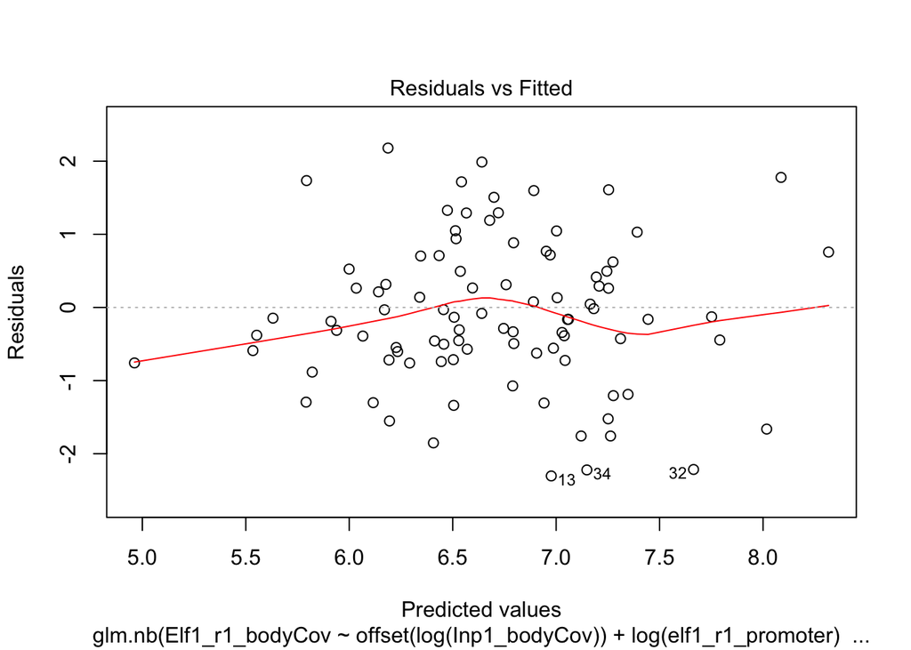

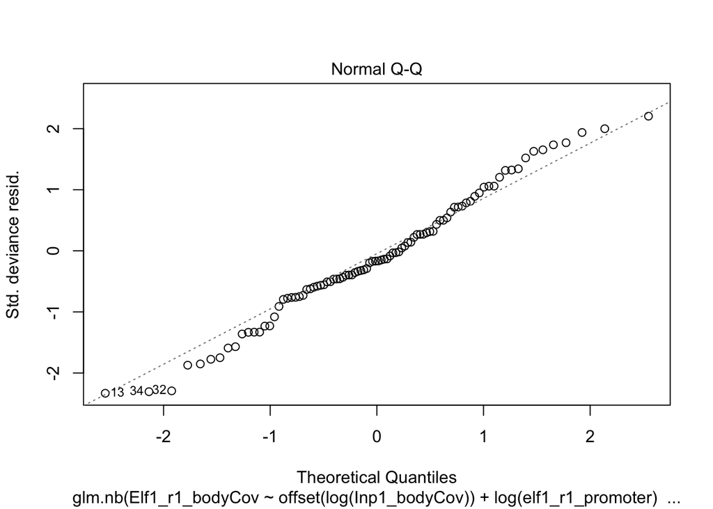

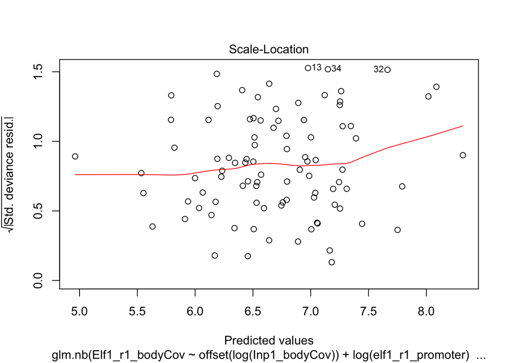

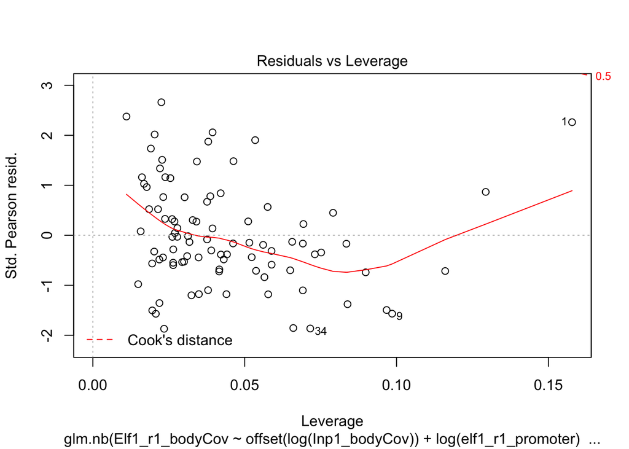

```r
#minimal model after feature selection
model.nb<-suppressWarnings(glm.nb(Elf1_r1_bodyCov ~ offset(log(Inp1_bodyCov)) + log(elf1_r1_promoter)  + log(TFEb_foldR1) + log(cpsf1_r1_promoter), data=dataMerged2, init.theta=5.1))
plot(model.nb)
```

```r
model.nb.dropCPSF1<-suppressWarnings(glm.nb(Elf1_r1_bodyCov ~ offset(log(Inp1_bodyCov)) + log(elf1_r1_promoter) + log(TFEb_foldR1), data=dataMerged2))

model.nb.dropElf1<-suppressWarnings(glm.nb(Elf1_r1_bodyCov ~ offset(log(Inp1_bodyCov)) +log(TFEb_foldR1) +  log(cpsf1_r1_promoter), data=dataMerged2))

model.nb.dropTFEb<-suppressWarnings(glm.nb(Elf1_r1_bodyCov ~ offset(log(Inp1_bodyCov)) + log(elf1_r1_promoter)  + log(cpsf1_r1_promoter), data=dataMerged2, init.theta=5.1))

#LR Elf1
anova(model.nb, model.nb.dropElf1, test = "Chisq")$`LR stat`[2]
```

```
## [1] 84.58136
```

```r
#p-value
anova(model.nb, model.nb.dropElf1, test = "Chisq")$`Pr(Chi)`[2]
```

```
## [1] 0
```

```r
#LR CPSF1
anova(model.nb, model.nb.dropCPSF1, test = "Chisq")$`LR stat`[2]
```

```
## [1] 6.19916
```

```r
#p-value
anova(model.nb, model.nb.dropCPSF1, test = "Chisq")$`Pr(Chi)`[2]
```

```
## [1] 0.0127811
```

```r
#LR TFEb
anova(model.nb, model.nb.dropTFEb, test = "Chisq")$`LR stat`[2]
```

```
## [1] 7.38522
```

```r
#p-value
anova(model.nb, model.nb.dropTFEb, test = "Chisq")$`Pr(Chi)`[2]
```

```
## [1] 0.006576204
```

```r
confint(Boot(model.nb,  f=coef, start=coef(model.nb), R=1000, method = "case"))
```

```
## Bootstrap bca confidence intervals
##
##                             2.5 %      97.5 %
## (Intercept)            -0.6810677 -0.14224742
## log(elf1_r1_promoter)   0.8048665  1.12362351
## log(TFEb_foldR1)        0.0793335  0.41295553
## log(cpsf1_r1_promoter) -0.4481772 -0.03429724
```

```r
#pseudo R^2
pR2(model.nb)
```

```
##          llh      llhNull           G2     McFadden         r2ML
## -626.4289325 -707.8817359  162.9056068    0.1150656    0.8297884
##         r2CU
##    0.8297886
```

Repeat for replicate 2

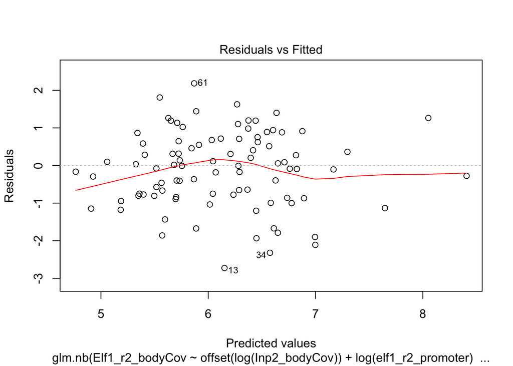

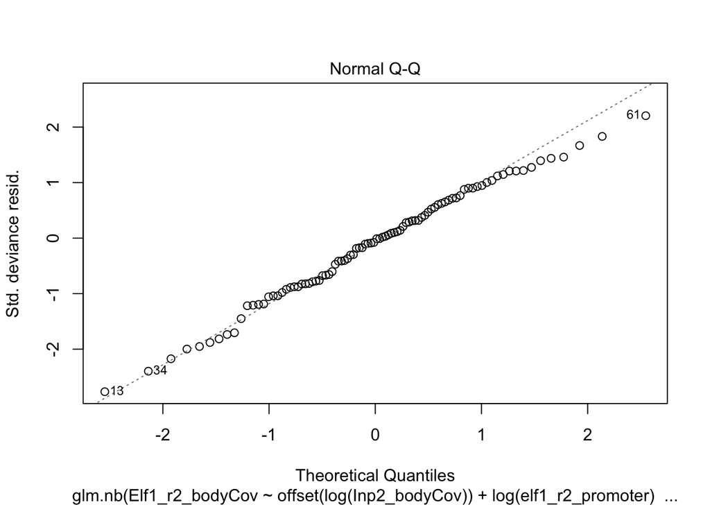

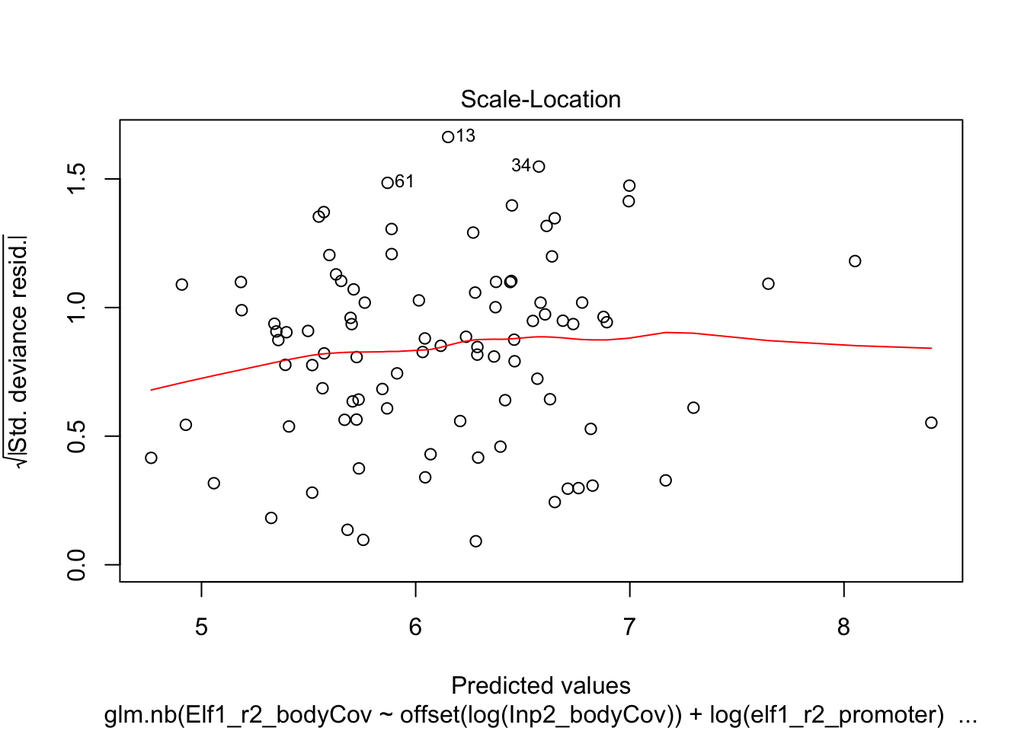

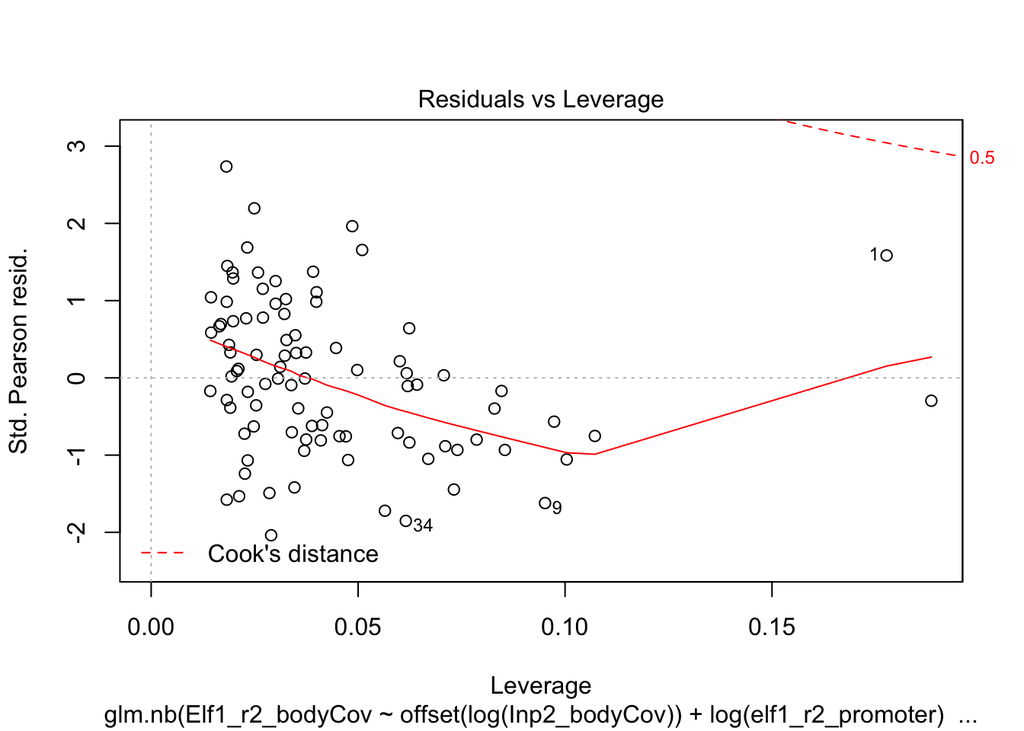

```r
model.nb<-suppressWarnings(glm.nb(Elf1_r2_bodyCov ~ offset(log(Inp2_bodyCov)) + log(elf1_r2_promoter)  + log(TFEb_foldR2) + log(cpsf1_r2_promoter), data=dataMerged2, init.theta=5.1))
plot(model.nb)
```

```r
model.nb.dropCPSF1<-suppressWarnings(glm.nb(Elf1_r2_bodyCov ~ offset(log(Inp2_bodyCov)) + log(elf1_r2_promoter) + log(TFEb_foldR2), data=dataMerged2))

model.nb.dropElf1<-suppressWarnings(glm.nb(Elf1_r2_bodyCov ~ offset(log(Inp2_bodyCov)) +log(TFEb_foldR2) +  log(cpsf1_r2_promoter), data=dataMerged2))

model.nb.dropTFEb<-suppressWarnings(glm.nb(Elf1_r2_bodyCov ~ offset(log(Inp2_bodyCov)) + log(elf1_r2_promoter)  + log(cpsf1_r2_promoter), data=dataMerged2, init.theta=5.1))

#LR Elf1
anova(model.nb, model.nb.dropElf1, test = "Chisq")$`LR stat`[2]
```

```
## [1] 78.4964
```

```r
#p-value
anova(model.nb, model.nb.dropElf1, test = "Chisq")$`Pr(Chi)`[2]
```

```
## [1] 0
```

```r
#LR CPSF1
anova(model.nb, model.nb.dropCPSF1, test = "Chisq")$`LR stat`[2]
```

```
## [1] 6.169706
```

```r
#p-value
anova(model.nb, model.nb.dropCPSF1, test = "Chisq")$`Pr(Chi)`[2]
```

```
## [1] 0.01299562
```

```r
#LR TFEb
anova(model.nb, model.nb.dropTFEb, test = "Chisq")$`LR stat`[2]
```

```
## [1] 7.282492
```

```r
#p-value
anova(model.nb, model.nb.dropTFEb, test = "Chisq")$`Pr(Chi)`[2]
```

```
## [1] 0.006962986
```

```r
confint(Boot(model.nb,  f=coef, start=coef(model.nb), R=1000, method = "case"))
```

```
## Bootstrap bca confidence intervals
##
##                              2.5 %      97.5 %
## (Intercept)            -1.30859627 -0.80088962
## log(elf1_r2_promoter)   0.88298810  1.25545675
## log(TFEb_foldR2)        0.08926239  0.48309377
## log(cpsf1_r2_promoter) -0.44025428 -0.03384152
```

```r
#pseudo R^2
pR2(model.nb)
```

```
##          llh      llhNull           G2     McFadden         r2ML
## -585.7961645 -670.9922739  170.3922187    0.1269703    0.8430910
##         r2CU
##    0.8430914
```

Automatic model selection with step() function including binary interaction terms

```r
#function to calculate BIC
bic<-function(model) {-model$twologlik  + (length(model$coefficients)+1) * log(nrow(model$model))}

model.null<- suppressWarnings(glm.nb(Elf1_r1_bodyCov ~ offset(log(Inp1_bodyCov)), data=dataMerged2))

#full model including all binary interaction terms
model.bin <- suppressWarnings(glm.nb(Elf1_r1_bodyCov ~ offset(log(Inp1_bodyCov)) + log(elf1_r1_promoter) + deltaG + log(TFB1_foldR1) + log(TFEb_foldR1) + log(cpsf1_r1_promoter) + I(log(elf1_r1_promoter)*deltaG) + I(log(elf1_r1_promoter)*log(TFB1_foldR1)) + I(log(elf1_r1_promoter)*log(TFEb_foldR1)) + I(log(elf1_r1_promoter)*log(cpsf1_r1_promoter)) + I(deltaG*log(TFB1_foldR1)) + I(deltaG*log(TFEb_foldR1)) + I(deltaG*log(cpsf1_r1_promoter)) + I(log(TFB1_foldR1)*log(TFEb_foldR1)) + I(log(TFB1_foldR1)*log(cpsf1_r1_promoter)) + I(log(TFEb_foldR1)*log(cpsf1_r1_promoter)), data=dataMerged2))

model.step<-step(object=model.null, scope=list(upper=model.bin$call, lower=model.null$call), data=dataMerged2, trace=F, direction = "forward", k = log(nrow(dataMerged2)))
bic(model.step)
```

```
## [1] 1271.781
```

```r
#trying to add single terms to starting model
model.step.spt45<-step(object=update(model.null,  ~ . + log(elf1_r1_promoter)), scope=list(upper=model.bin$call, lower=~1), data=dataMerged2, trace=F, direction = "forward", k = log(nrow(dataMerged2)))
bic(model.step.spt45)
```

```
## [1] 1271.781
```

```r
model.step.deltaG<-step(object=update(model.null,  ~ . + deltaG), scope=list(upper=model.bin$call, lower=~1), data=dataMerged2, trace=F, direction = "forward", k = log(nrow(dataMerged2)))
bic(model.step.deltaG)
```

```
## [1] 1274.827
```

```r
model.step.TFB<-step(object=update(model.null,  ~ . + log(TFB1_foldR1)), scope=list(upper=model.bin$call, lower=~1), data=dataMerged2, trace=F, direction = "forward", k = log(nrow(dataMerged2)))
bic(model.step.TFB)
```

```
## [1] 1277.505
```

```r
model.step.TFEb<-step(object=update(model.null,  ~ . + log(TFEb_foldR1)), scope=list(upper=model.bin$call, lower=~1), data=dataMerged2, trace=F, direction = "forward", k = log(nrow(dataMerged2)))
bic(model.step.TFEb)
```

```
## [1] 1275.467
```

```r
model.step.cpsf1<-step(object=update(model.null,  ~ . + log(cpsf1_r1_promoter)), scope=list(upper=model.bin$call, lower=~1), data=dataMerged2, trace=F, direction = "forward", k = log(nrow(dataMerged2)))
bic(model.step.cpsf1)
```

```
## [1] 1274.001
```

```r
#model with lowest BIC
model.step$call
```

```
## glm.nb(formula = Elf1_r1_bodyCov ~ log(elf1_r1_promoter) + I(log(elf1_r1_promoter) *
##     log(TFEb_foldR1)) + I(log(elf1_r1_promoter) * log(cpsf1_r1_promoter)) +
##     offset(log(Inp1_bodyCov)), data = dataMerged2, init.theta = 13.96903261,
##     link = log)
```

Identical with minimal model besides the interaction terms for TFEb and aCPSF1 with Elf1!

Model for replicate 1 with minimal BIC contains binary interaction terms for CPSF1 and TFEb. Testing significance

```r
anova(model.step, update(model.step, ~.-log(elf1_r1_promoter)))
```

```
## Likelihood ratio tests of Negative Binomial Models
##
## Response: Elf1_r1_bodyCov
##                                                                                                                                                 Model
## 1                         I(log(elf1_r1_promoter) * log(TFEb_foldR1)) + I(log(elf1_r1_promoter) * log(cpsf1_r1_promoter)) + offset(log(Inp1_bodyCov))
## 2 log(elf1_r1_promoter) + I(log(elf1_r1_promoter) * log(TFEb_foldR1)) + I(log(elf1_r1_promoter) * log(cpsf1_r1_promoter)) + offset(log(Inp1_bodyCov))
##       theta Resid. df    2 x log-lik.   Test    df LR stat.      Pr(Chi)
## 1  9.861144        89       -1281.848
## 2 13.969033        88       -1249.172 1 vs 2     1 32.67612 1.088666e-08
```

```r
anova(model.step, update(model.step, ~.-I(log(elf1_r1_promoter) *
    log(TFEb_foldR1))))
```

```
## Likelihood ratio tests of Negative Binomial Models
##
## Response: Elf1_r1_bodyCov
##                                                                                                                                                 Model
## 1                                               log(elf1_r1_promoter) + I(log(elf1_r1_promoter) * log(cpsf1_r1_promoter)) + offset(log(Inp1_bodyCov))
## 2 log(elf1_r1_promoter) + I(log(elf1_r1_promoter) * log(TFEb_foldR1)) + I(log(elf1_r1_promoter) * log(cpsf1_r1_promoter)) + offset(log(Inp1_bodyCov))
##      theta Resid. df    2 x log-lik.   Test    df LR stat.      Pr(Chi)
## 1 12.08010        89       -1262.571
## 2 13.96903        88       -1249.172 1 vs 2     1 13.39838 0.0002518413
```

```r
anova(model.step, update(model.step, ~.-I(log(elf1_r1_promoter) *
    log(cpsf1_r1_promoter))))
```

```
## Likelihood ratio tests of Negative Binomial Models
##
## Response: Elf1_r1_bodyCov
##                                                                                                                                                 Model
## 1                                                     log(elf1_r1_promoter) + I(log(elf1_r1_promoter) * log(TFEb_foldR1)) + offset(log(Inp1_bodyCov))
## 2 log(elf1_r1_promoter) + I(log(elf1_r1_promoter) * log(TFEb_foldR1)) + I(log(elf1_r1_promoter) * log(cpsf1_r1_promoter)) + offset(log(Inp1_bodyCov))
##      theta Resid. df    2 x log-lik.   Test    df LR stat.     Pr(Chi)
## 1 12.69106        89       -1258.122
## 2 13.96903        88       -1249.172 1 vs 2     1 8.949466 0.002775507
```

Retesting model optimisation for 2nd replicate

```r
model.null<- suppressWarnings(glm.nb(Elf1_r2_bodyCov ~ offset(log(Inp2_bodyCov)), data=dataMerged2))
#full model including all binary interaction terms
model.bin <- suppressWarnings(glm.nb(Elf1_r2_bodyCov ~ offset(log(Inp2_bodyCov)) + log(elf1_r2_promoter) + deltaG + log(TFB1_foldR2) + log(TFEb_foldR2) + log(cpsf1_r2_promoter) + I(log(elf1_r2_promoter)*deltaG) + I(log(elf1_r2_promoter)*log(TFB1_foldR2)) + I(log(elf1_r2_promoter)*log(TFEb_foldR2)) + I(log(elf1_r2_promoter)*log(cpsf1_r2_promoter)) + I(deltaG*log(TFB1_foldR2)) + I(deltaG*log(TFEb_foldR2)) + I(deltaG*log(cpsf1_r2_promoter)) + I(log(TFB1_foldR2)*log(TFEb_foldR2)) + I(log(TFB1_foldR2)*log(cpsf1_r2_promoter)) + I(log(TFEb_foldR2)*log(cpsf1_r2_promoter)), data=dataMerged2))

model.step<-step(object=model.null, scope=list(upper=model.bin$call, lower=model.null$call), data=dataMerged2, trace=F, direction = "forward", k = log(nrow(dataMerged2)))
bic(model.step)
```

```
## [1] 1189.714
```

```r
#trying to add single terms to starting model
model.step.spt45<-step(object=update(model.null,  ~ . + log(elf1_r2_promoter)), scope=list(upper=model.bin$call, lower=~1), data=dataMerged2, trace=F, direction = "forward", k = log(nrow(dataMerged2)))
bic(model.step.spt45)
```

```
## [1] 1189.714
```

```r
model.step.deltaG<-step(object=update(model.null,  ~ . + deltaG), scope=list(upper=model.bin$call, lower=~1), data=dataMerged2, trace=F, direction = "forward", k = log(nrow(dataMerged2)))
bic(model.step.deltaG)
```

```
## [1] 1193.468
```

```r
model.step.TFB<-step(object=update(model.null,  ~ . + log(TFB1_foldR2)), scope=list(upper=model.bin$call, lower=~1), data=dataMerged2, trace=F, direction = "forward", k = log(nrow(dataMerged2)))
bic(model.step.TFB)
```

```
## [1] 1192.602
```

```r
model.step.TFEb<-step(object=update(model.null,  ~ . + log(TFEb_foldR2)), scope=list(upper=model.bin$call, lower=~1), data=dataMerged2, trace=F, direction = "forward", k = log(nrow(dataMerged2)))
bic(model.step.TFEb)
```

```
## [1] 1194.201
```

```r
model.step.cpsf1<-step(object=update(model.null,  ~ . + log(cpsf1_r2_promoter)), scope=list(upper=model.bin$call, lower=~1), data=dataMerged2, trace=F, direction = "forward", k = log(nrow(dataMerged2)))
bic(model.step.cpsf1)
```

```
## [1] 1192.876
```

```r
#model with lowest BIC
model.step$call
```

```
## glm.nb(formula = Elf1_r2_bodyCov ~ log(elf1_r2_promoter) + I(log(elf1_r2_promoter) *
##     log(TFEb_foldR2)) + I(log(elf1_r2_promoter) * log(cpsf1_r2_promoter)) +
##     offset(log(Inp2_bodyCov)), data = dataMerged2, init.theta = 10.59278269,
##     link = log)
```

Testing significance for second biol. replicate

```r
anova(model.step, update(model.step, ~.-log(elf1_r2_promoter)))
```

```
## Likelihood ratio tests of Negative Binomial Models
##
## Response: Elf1_r2_bodyCov
##                                                                                                                                                 Model
## 1                         I(log(elf1_r2_promoter) * log(TFEb_foldR2)) + I(log(elf1_r2_promoter) * log(cpsf1_r2_promoter)) + offset(log(Inp2_bodyCov))
## 2 log(elf1_r2_promoter) + I(log(elf1_r2_promoter) * log(TFEb_foldR2)) + I(log(elf1_r2_promoter) * log(cpsf1_r2_promoter)) + offset(log(Inp2_bodyCov))
##       theta Resid. df    2 x log-lik.   Test    df LR stat.      Pr(Chi)
## 1  7.074861        89       -1204.977
## 2 10.592783        88       -1167.105 1 vs 2     1 37.87284 7.550902e-10
```

```r
anova(model.step, update(model.step, ~.-I(log(elf1_r2_promoter) *
    log(TFEb_foldR2))))
```

```
## Likelihood ratio tests of Negative Binomial Models
##
## Response: Elf1_r2_bodyCov
##                                                                                                                                                 Model
## 1                                               log(elf1_r2_promoter) + I(log(elf1_r2_promoter) * log(cpsf1_r2_promoter)) + offset(log(Inp2_bodyCov))
## 2 log(elf1_r2_promoter) + I(log(elf1_r2_promoter) * log(TFEb_foldR2)) + I(log(elf1_r2_promoter) * log(cpsf1_r2_promoter)) + offset(log(Inp2_bodyCov))
##       theta Resid. df    2 x log-lik.   Test    df LR stat.      Pr(Chi)
## 1  9.026024        89       -1181.827
## 2 10.592783        88       -1167.105 1 vs 2     1 14.72208 0.0001245789
```

```r
anova(model.step, update(model.step, ~.-I(log(elf1_r2_promoter) *
    log(cpsf1_r2_promoter))))
```

```
## Likelihood ratio tests of Negative Binomial Models
##
## Response: Elf1_r2_bodyCov
##                                                                                                                                                 Model
## 1                                                     log(elf1_r2_promoter) + I(log(elf1_r2_promoter) * log(TFEb_foldR2)) + offset(log(Inp2_bodyCov))
## 2 log(elf1_r2_promoter) + I(log(elf1_r2_promoter) * log(TFEb_foldR2)) + I(log(elf1_r2_promoter) * log(cpsf1_r2_promoter)) + offset(log(Inp2_bodyCov))
##       theta Resid. df    2 x log-lik.   Test    df LR stat.     Pr(Chi)
## 1  9.586197        89       -1176.397
## 2 10.592783        88       -1167.105 1 vs 2     1  9.29197 0.002301606
```